# Risk Factor Analysis

## Outcome Variable

**Outcome Variable:** whz

## Predictor Variables

**Intervention Variable:** mbmi

**Adjustment Set:**

- arm
- W_mage
- W_fage
- meducyrs
- feducyrs
- single
- brthmon
- W_gagebrth
- W_birthwt
- W_birthlen
- vagbrth
- delta_W_mage
- delta_W_fage
- delta_meducyrs
- delta_feducyrs
- delta_single
- delta_brthmon
- delta_W_gagebrth
- delta_W_birthwt
- delta_W_birthlen
- delta_vagbrth

## Stratifying Variables

The analysis was stratified on these variable(s):

- agecat
- studyid
- country

## Data Summary

| agecat | studyid | country | mbmi | n_cell | n |
| --- | --- | --- | --- | --- | --- |
| 6 months | LCNI-5 | MALAWI | Normal weight | 691 | 836 |
| 6 months | LCNI-5 | MALAWI | Underweight | 145 | 836 |
| 6 months | MAL-ED | BANGLADESH | Normal weight | 209 | 241 |
| 6 months | MAL-ED | BANGLADESH | Underweight | 32 | 241 |
| 6 months | MAL-ED | BRAZIL | Normal weight | 199 | 208 |
| 6 months | MAL-ED | BRAZIL | Underweight | 9 | 208 |
| 6 months | MAL-ED | INDIA | Normal weight | 186 | 235 |
| 6 months | MAL-ED | INDIA | Underweight | 49 | 235 |
| 6 months | MAL-ED | NEPAL | Normal weight | 236 | 236 |
| 6 months | MAL-ED | NEPAL | Underweight | 0 | 236 |
| 6 months | MAL-ED | PERU | Normal weight | 267 | 272 |
| 6 months | MAL-ED | PERU | Underweight | 5 | 272 |
| 6 months | MAL-ED | SOUTH AFRICA | Normal weight | 242 | 249 |
| 6 months | MAL-ED | SOUTH AFRICA | Underweight | 7 | 249 |
| 6 months | MAL-ED | TANZANIA, UNITED REPUBLIC OF | Normal weight | 233 | 247 |
| 6 months | MAL-ED | TANZANIA, UNITED REPUBLIC OF | Underweight | 14 | 247 |
| 6 months | NIH-Birth | BANGLADESH | Normal weight | 444 | 537 |
| 6 months | NIH-Birth | BANGLADESH | Underweight | 93 | 537 |
| 6 months | NIH-Crypto | BANGLADESH | Normal weight | 648 | 715 |
| 6 months | NIH-Crypto | BANGLADESH | Underweight | 67 | 715 |
| 6 months | PROBIT | BELARUS | Normal weight | 12518 | 13023 |
| 6 months | PROBIT | BELARUS | Underweight | 505 | 13023 |
| 6 months | PROVIDE | BANGLADESH | Normal weight | 497 | 602 |
| 6 months | PROVIDE | BANGLADESH | Underweight | 105 | 602 |
| 6 months | SAS-CompFeed | INDIA | Normal weight | 921 | 1225 |
| 6 months | SAS-CompFeed | INDIA | Underweight | 304 | 1225 |
| 6 months | TanzaniaChild2 | TANZANIA, UNITED REPUBLIC OF | Normal weight | 1949 | 1982 |
| 6 months | TanzaniaChild2 | TANZANIA, UNITED REPUBLIC OF | Underweight | 33 | 1982 |
| 6 months | ZVITAMBO | ZIMBABWE | Normal weight | 6881 | 7253 |
| 6 months | ZVITAMBO | ZIMBABWE | Underweight | 372 | 7253 |
| 24 months | LCNI-5 | MALAWI | Normal weight | 467 | 561 |
| 24 months | LCNI-5 | MALAWI | Underweight | 94 | 561 |
| 24 months | MAL-ED | BANGLADESH | Normal weight | 183 | 212 |
| 24 months | MAL-ED | BANGLADESH | Underweight | 29 | 212 |
| 24 months | MAL-ED | BRAZIL | Normal weight | 162 | 168 |
| 24 months | MAL-ED | BRAZIL | Underweight | 6 | 168 |
| 24 months | MAL-ED | INDIA | Normal weight | 180 | 226 |
| 24 months | MAL-ED | INDIA | Underweight | 46 | 226 |
| 24 months | MAL-ED | NEPAL | Normal weight | 228 | 228 |
| 24 months | MAL-ED | NEPAL | Underweight | 0 | 228 |
| 24 months | MAL-ED | PERU | Normal weight | 197 | 201 |
| 24 months | MAL-ED | PERU | Underweight | 4 | 201 |
| 24 months | MAL-ED | SOUTH AFRICA | Normal weight | 227 | 234 |
| 24 months | MAL-ED | SOUTH AFRICA | Underweight | 7 | 234 |
| 24 months | MAL-ED | TANZANIA, UNITED REPUBLIC OF | Normal weight | 203 | 214 |
| 24 months | MAL-ED | TANZANIA, UNITED REPUBLIC OF | Underweight | 11 | 214 |
| 24 months | NIH-Birth | BANGLADESH | Normal weight | 348 | 428 |
| 24 months | NIH-Birth | BANGLADESH | Underweight | 80 | 428 |
| 24 months | NIH-Crypto | BANGLADESH | Normal weight | 471 | 514 |
| 24 months | NIH-Crypto | BANGLADESH | Underweight | 43 | 514 |
| 24 months | PROBIT | BELARUS | Normal weight | 3799 | 3940 |
| 24 months | PROBIT | BELARUS | Underweight | 141 | 3940 |
| 24 months | PROVIDE | BANGLADESH | Normal weight | 478 | 578 |
| 24 months | PROVIDE | BANGLADESH | Underweight | 100 | 578 |
| 24 months | TanzaniaChild2 | TANZANIA, UNITED REPUBLIC OF | Normal weight | 6 | 6 |
| 24 months | TanzaniaChild2 | TANZANIA, UNITED REPUBLIC OF | Underweight | 0 | 6 |
| 24 months | ZVITAMBO | ZIMBABWE | Normal weight | 339 | 366 |
| 24 months | ZVITAMBO | ZIMBABWE | Underweight | 27 | 366 |

The following strata were considered:

- agecat: 24 months, studyid: LCNI-5, country: MALAWI
- agecat: 24 months, studyid: MAL-ED, country: BANGLADESH
- agecat: 24 months, studyid: MAL-ED, country: BRAZIL
- agecat: 24 months, studyid: MAL-ED, country: INDIA
- agecat: 24 months, studyid: MAL-ED, country: NEPAL
- agecat: 24 months, studyid: MAL-ED, country: PERU
- agecat: 24 months, studyid: MAL-ED, country: SOUTH AFRICA
- agecat: 24 months, studyid: MAL-ED, country: TANZANIA, UNITED REPUBLIC OF
- agecat: 24 months, studyid: NIH-Birth, country: BANGLADESH
- agecat: 24 months, studyid: NIH-Crypto, country: BANGLADESH
- agecat: 24 months, studyid: PROBIT, country: BELARUS
- agecat: 24 months, studyid: PROVIDE, country: BANGLADESH
- agecat: 24 months, studyid: TanzaniaChild2, country: TANZANIA, UNITED REPUBLIC OF
- agecat: 24 months, studyid: ZVITAMBO, country: ZIMBABWE
- agecat: 6 months, studyid: LCNI-5, country: MALAWI
- agecat: 6 months, studyid: MAL-ED, country: BANGLADESH
- agecat: 6 months, studyid: MAL-ED, country: BRAZIL
- agecat: 6 months, studyid: MAL-ED, country: INDIA
- agecat: 6 months, studyid: MAL-ED, country: NEPAL
- agecat: 6 months, studyid: MAL-ED, country: PERU
- agecat: 6 months, studyid: MAL-ED, country: SOUTH AFRICA
- agecat: 6 months, studyid: MAL-ED, country: TANZANIA, UNITED REPUBLIC OF
- agecat: 6 months, studyid: NIH-Birth, country: BANGLADESH
- agecat: 6 months, studyid: NIH-Crypto, country: BANGLADESH
- agecat: 6 months, studyid: PROBIT, country: BELARUS
- agecat: 6 months, studyid: PROVIDE, country: BANGLADESH
- agecat: 6 months, studyid: SAS-CompFeed, country: INDIA
- agecat: 6 months, studyid: TanzaniaChild2, country: TANZANIA, UNITED REPUBLIC OF
- agecat: 6 months, studyid: ZVITAMBO, country: ZIMBABWE

### Dropped Strata

- agecat: 6 months, studyid: MAL-ED, country: NEPAL
- agecat: 24 months, studyid: MAL-ED, country: NEPAL
- agecat: 24 months, studyid: MAL-ED, country: PERU
- agecat: 24 months, studyid: TanzaniaChild2, country: TANZANIA, UNITED REPUBLIC OF

## Methods Detail

We’re interested in the causal parameters $E[Y_a]$ for all values of $a \in \mathcal{A}$. These parameters represent the mean outcome if, possibly contrary to fact, we intervened to set all units to have $A=a$. Under the randomization and positivity assumptions, these are identified by the statistical parameters $\psi_a=E_W[E_{Y|A,W}(Y|A=a,W)]$. In addition, we’re interested in the mean of $Y$, $E[Y]$ under no intervention (the observed mean). We will estimate these parameters by using SuperLearner to fit the relevant likelihood factors – $E_{Y|A,W}(Y|A=a,W)$ and $p(A=a|W)$, and then updating our likelihood fit using a joint TMLE.

For unadjusted analyses ($W=\{\}$), initial likelihoods were estimated using Lrnr_glm to estimate the simple $E(Y|A)$ and Lrnr_mean to estimate $p(A)$. For adjusted analyses, a small library containing Lrnr_glmnet, Lrnr_xgboost, and Lrnr_mean was used.

Having estimated these parameters, we will then use the delta method to estimate relative risks and attributable risks relative to a prespecified baseline level of $A$.

# Results Detail

## Results Plots

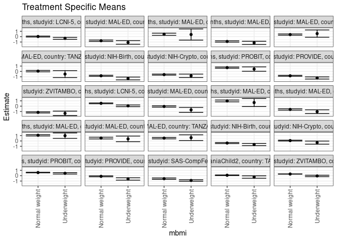

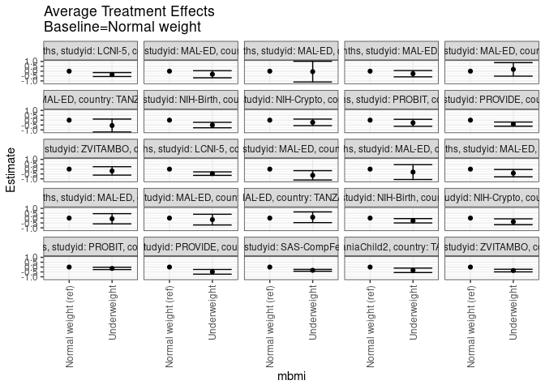

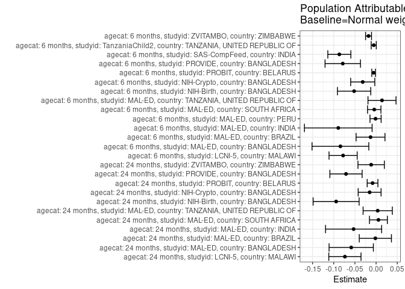

## Results Table

### Parameter: TSM

| agecat | studyid | country | intervention_level | baseline_level | estimate | ci_lower | ci_upper |
| --- | --- | --- | --- | --- | --- | --- | --- |
| 6 months | LCNI-5 | MALAWI | Normal weight | NA | 0.5294323 | 0.4512113 | 0.6076533 |
| 6 months | LCNI-5 | MALAWI | Underweight | NA | 0.0662638 | -0.0944862 | 0.2270139 |
| 6 months | MAL-ED | BANGLADESH | Normal weight | NA | -0.0534366 | -0.1821426 | 0.0752695 |
| 6 months | MAL-ED | BANGLADESH | Underweight | NA | -0.6896685 | -1.1506871 | -0.2286499 |
| 6 months | MAL-ED | BRAZIL | Normal weight | NA | 0.9779606 | 0.8096461 | 1.1462751 |
| 6 months | MAL-ED | BRAZIL | Underweight | NA | 0.6750000 | -0.0698801 | 1.4198801 |
| 6 months | MAL-ED | INDIA | Normal weight | NA | -0.6141360 | -0.7487150 | -0.4795571 |
| 6 months | MAL-ED | INDIA | Underweight | NA | -1.0286753 | -1.3785710 | -0.6787795 |
| 6 months | MAL-ED | PERU | Normal weight | NA | 1.0561298 | 0.9317231 | 1.1805366 |
| 6 months | MAL-ED | PERU | Underweight | NA | 0.9870000 | 0.4781587 | 1.4958413 |
| 6 months | MAL-ED | SOUTH AFRICA | Normal weight | NA | 0.5335468 | 0.3758513 | 0.6912424 |
| 6 months | MAL-ED | SOUTH AFRICA | Underweight | NA | 0.3771429 | -0.1498294 | 0.9041151 |
| 6 months | MAL-ED | TANZANIA, UNITED REPUBLIC OF | Normal weight | NA | 0.5222810 | 0.3870735 | 0.6574885 |
| 6 months | MAL-ED | TANZANIA, UNITED REPUBLIC OF | Underweight | NA | 0.6081056 | 0.0744864 | 1.1417249 |
| 6 months | NIH-Birth | BANGLADESH | Normal weight | NA | -0.3955120 | -0.4944877 | -0.2965364 |
| 6 months | NIH-Birth | BANGLADESH | Underweight | NA | -0.6708188 | -0.8760500 | -0.4655876 |
| 6 months | NIH-Crypto | BANGLADESH | Normal weight | NA | 0.0613153 | -0.0201192 | 0.1427499 |
| 6 months | NIH-Crypto | BANGLADESH | Underweight | NA | -0.3164444 | -0.6071531 | -0.0257358 |
| 6 months | PROBIT | BELARUS | Normal weight | NA | 0.5843168 | 0.5259980 | 0.6426357 |
| 6 months | PROBIT | BELARUS | Underweight | NA | 0.4459208 | 0.3104823 | 0.5813592 |
| 6 months | PROVIDE | BANGLADESH | Normal weight | NA | -0.1200023 | -0.2103068 | -0.0296977 |
| 6 months | PROVIDE | BANGLADESH | Underweight | NA | -0.6074738 | -0.8293257 | -0.3856218 |
| 6 months | SAS-CompFeed | INDIA | Normal weight | NA | -0.5573196 | -0.6890270 | -0.4256123 |
| 6 months | SAS-CompFeed | INDIA | Underweight | NA | -0.8916468 | -1.0332166 | -0.7500769 |
| 6 months | TanzaniaChild2 | TANZANIA, UNITED REPUBLIC OF | Normal weight | NA | 0.0830737 | 0.0287353 | 0.1374122 |
| 6 months | TanzaniaChild2 | TANZANIA, UNITED REPUBLIC OF | Underweight | NA | -0.2527963 | -0.4738587 | -0.0317340 |
| 6 months | ZVITAMBO | ZIMBABWE | Normal weight | NA | 0.3126233 | 0.2844772 | 0.3407695 |
| 6 months | ZVITAMBO | ZIMBABWE | Underweight | NA | -0.0456730 | -0.1779909 | 0.0866448 |
| 24 months | LCNI-5 | MALAWI | Normal weight | NA | 0.0267477 | -0.0625640 | 0.1160595 |
| 24 months | LCNI-5 | MALAWI | Underweight | NA | -0.3189962 | -0.5019738 | -0.1360185 |
| 24 months | MAL-ED | BANGLADESH | Normal weight | NA | -0.7605767 | -0.8910020 | -0.6301513 |
| 24 months | MAL-ED | BANGLADESH | Underweight | NA | -1.0762041 | -1.4165939 | -0.7358143 |
| 24 months | MAL-ED | BRAZIL | Normal weight | NA | 0.4461317 | 0.2381826 | 0.6540808 |
| 24 months | MAL-ED | BRAZIL | Underweight | NA | 0.3966667 | -0.6451983 | 1.4385316 |
| 24 months | MAL-ED | INDIA | Normal weight | NA | -0.8988061 | -1.0227912 | -0.7748209 |
| 24 months | MAL-ED | INDIA | Underweight | NA | -1.1570114 | -1.4565812 | -0.8574415 |
| 24 months | MAL-ED | SOUTH AFRICA | Normal weight | NA | 0.3861417 | 0.2630585 | 0.5092249 |
| 24 months | MAL-ED | SOUTH AFRICA | Underweight | NA | 0.5700000 | -0.1123856 | 1.2523856 |
| 24 months | MAL-ED | TANZANIA, UNITED REPUBLIC OF | Normal weight | NA | 0.0509824 | -0.0763201 | 0.1782850 |
| 24 months | MAL-ED | TANZANIA, UNITED REPUBLIC OF | Underweight | NA | -0.5007818 | -1.1521663 | 0.1506026 |
| 24 months | NIH-Birth | BANGLADESH | Normal weight | NA | -0.8172336 | -0.9205402 | -0.7139271 |
| 24 months | NIH-Birth | BANGLADESH | Underweight | NA | -1.3187884 | -1.5818381 | -1.0557386 |
| 24 months | NIH-Crypto | BANGLADESH | Normal weight | NA | -0.5950792 | -0.6938054 | -0.4963529 |
| 24 months | NIH-Crypto | BANGLADESH | Underweight | NA | -0.8238984 | -1.1448686 | -0.5029281 |
| 24 months | PROBIT | BELARUS | Normal weight | NA | 0.7075045 | 0.5947874 | 0.8202216 |
| 24 months | PROBIT | BELARUS | Underweight | NA | 0.4337007 | 0.0292879 | 0.8381136 |
| 24 months | PROVIDE | BANGLADESH | Normal weight | NA | -0.8204177 | -0.9091932 | -0.7316423 |
| 24 months | PROVIDE | BANGLADESH | Underweight | NA | -1.2277657 | -1.4268566 | -1.0286749 |
| 24 months | ZVITAMBO | ZIMBABWE | Normal weight | NA | -1.1601971 | -1.2735174 | -1.0468768 |
| 24 months | ZVITAMBO | ZIMBABWE | Underweight | NA | -1.3450241 | -1.7640529 | -0.9259953 |

### Parameter: E(Y)

| agecat | studyid | country | intervention_level | baseline_level | estimate | ci_lower | ci_upper |
| --- | --- | --- | --- | --- | --- | --- | --- |
| 6 months | LCNI-5 | MALAWI | NA | NA | 0.4515550 | 0.3802638 | 0.5228463 |
| 6 months | MAL-ED | BANGLADESH | NA | NA | -0.1376763 | -0.2664642 | -0.0088885 |
| 6 months | MAL-ED | BRAZIL | NA | NA | 0.9648518 | 0.8004118 | 1.1292917 |
| 6 months | MAL-ED | INDIA | NA | NA | -0.7034149 | -0.8300527 | -0.5767771 |
| 6 months | MAL-ED | PERU | NA | NA | 1.0548591 | 0.9328922 | 1.1768259 |
| 6 months | MAL-ED | SOUTH AFRICA | NA | NA | 0.5291499 | 0.3751396 | 0.6831602 |
| 6 months | MAL-ED | TANZANIA, UNITED REPUBLIC OF | NA | NA | 0.5362213 | 0.4049390 | 0.6675036 |
| 6 months | NIH-Birth | BANGLADESH | NA | NA | -0.4474038 | -0.5378167 | -0.3569909 |
| 6 months | NIH-Crypto | BANGLADESH | NA | NA | 0.0297622 | -0.0491685 | 0.1086930 |
| 6 months | PROBIT | BELARUS | NA | NA | 0.5785149 | 0.5197782 | 0.6372516 |
| 6 months | PROVIDE | BANGLADESH | NA | NA | -0.1987071 | -0.2815473 | -0.1158669 |
| 6 months | SAS-CompFeed | INDIA | NA | NA | -0.6441020 | -0.7710827 | -0.5171213 |
| 6 months | TanzaniaChild2 | TANZANIA, UNITED REPUBLIC OF | NA | NA | 0.0775172 | 0.0241750 | 0.1308595 |
| 6 months | ZVITAMBO | ZIMBABWE | NA | NA | 0.2948332 | 0.2672524 | 0.3224139 |
| 24 months | LCNI-5 | MALAWI | NA | NA | -0.0468717 | -0.1290135 | 0.0352701 |
| 24 months | MAL-ED | BANGLADESH | NA | NA | -0.8192925 | -0.9412667 | -0.6973182 |
| 24 months | MAL-ED | BRAZIL | NA | NA | 0.4443651 | 0.2404149 | 0.6483153 |
| 24 months | MAL-ED | INDIA | NA | NA | -0.9519248 | -1.0678488 | -0.8360007 |
| 24 months | MAL-ED | SOUTH AFRICA | NA | NA | 0.3916417 | 0.2704414 | 0.5128421 |
| 24 months | MAL-ED | TANZANIA, UNITED REPUBLIC OF | NA | NA | 0.0547975 | -0.0703378 | 0.1799328 |
| 24 months | NIH-Birth | BANGLADESH | NA | NA | -0.9115790 | -1.0095022 | -0.8136559 |
| 24 months | NIH-Crypto | BANGLADESH | NA | NA | -0.6103502 | -0.7050157 | -0.5156847 |
| 24 months | PROBIT | BELARUS | NA | NA | 0.6991214 | 0.5821715 | 0.8160713 |
| 24 months | PROVIDE | BANGLADESH | NA | NA | -0.8914360 | -0.9741797 | -0.8086923 |
| 24 months | ZVITAMBO | ZIMBABWE | NA | NA | -1.1718579 | -1.2809898 | -1.0627260 |

### Parameter: ATE

| agecat | studyid | country | intervention_level | baseline_level | estimate | ci_lower | ci_upper |
| --- | --- | --- | --- | --- | --- | --- | --- |
| 6 months | LCNI-5 | MALAWI | Normal weight | Normal weight | 0.0000000 | 0.0000000 | 0.0000000 |
| 6 months | LCNI-5 | MALAWI | Underweight | Normal weight | -0.4631684 | -0.6422215 | -0.2841153 |
| 6 months | MAL-ED | BANGLADESH | Normal weight | Normal weight | 0.0000000 | 0.0000000 | 0.0000000 |
| 6 months | MAL-ED | BANGLADESH | Underweight | Normal weight | -0.6362319 | -1.1149463 | -0.1575175 |
| 6 months | MAL-ED | BRAZIL | Normal weight | Normal weight | 0.0000000 | 0.0000000 | 0.0000000 |
| 6 months | MAL-ED | BRAZIL | Underweight | Normal weight | -0.3029606 | -1.0666204 | 0.4606991 |
| 6 months | MAL-ED | INDIA | Normal weight | Normal weight | 0.0000000 | 0.0000000 | 0.0000000 |
| 6 months | MAL-ED | INDIA | Underweight | Normal weight | -0.4145392 | -0.7919561 | -0.0371223 |
| 6 months | MAL-ED | PERU | Normal weight | Normal weight | 0.0000000 | 0.0000000 | 0.0000000 |
| 6 months | MAL-ED | PERU | Underweight | Normal weight | -0.0691298 | -0.5929586 | 0.4546989 |
| 6 months | MAL-ED | SOUTH AFRICA | Normal weight | Normal weight | 0.0000000 | 0.0000000 | 0.0000000 |
| 6 months | MAL-ED | SOUTH AFRICA | Underweight | Normal weight | -0.1564040 | -0.7064654 | 0.3936575 |
| 6 months | MAL-ED | TANZANIA, UNITED REPUBLIC OF | Normal weight | Normal weight | 0.0000000 | 0.0000000 | 0.0000000 |
| 6 months | MAL-ED | TANZANIA, UNITED REPUBLIC OF | Underweight | Normal weight | 0.0858247 | -0.4652910 | 0.6369404 |
| 6 months | NIH-Birth | BANGLADESH | Normal weight | Normal weight | 0.0000000 | 0.0000000 | 0.0000000 |
| 6 months | NIH-Birth | BANGLADESH | Underweight | Normal weight | -0.2753068 | -0.4999022 | -0.0507114 |
| 6 months | NIH-Crypto | BANGLADESH | Normal weight | Normal weight | 0.0000000 | 0.0000000 | 0.0000000 |
| 6 months | NIH-Crypto | BANGLADESH | Underweight | Normal weight | -0.3777598 | -0.6795191 | -0.0760004 |
| 6 months | PROBIT | BELARUS | Normal weight | Normal weight | 0.0000000 | 0.0000000 | 0.0000000 |
| 6 months | PROBIT | BELARUS | Underweight | Normal weight | -0.1383961 | -0.2573469 | -0.0194452 |
| 6 months | PROVIDE | BANGLADESH | Normal weight | Normal weight | 0.0000000 | 0.0000000 | 0.0000000 |
| 6 months | PROVIDE | BANGLADESH | Underweight | Normal weight | -0.4874715 | -0.7274635 | -0.2474795 |
| 6 months | SAS-CompFeed | INDIA | Normal weight | Normal weight | 0.0000000 | 0.0000000 | 0.0000000 |
| 6 months | SAS-CompFeed | INDIA | Underweight | Normal weight | -0.3343271 | -0.4299385 | -0.2387157 |
| 6 months | TanzaniaChild2 | TANZANIA, UNITED REPUBLIC OF | Normal weight | Normal weight | 0.0000000 | 0.0000000 | 0.0000000 |
| 6 months | TanzaniaChild2 | TANZANIA, UNITED REPUBLIC OF | Underweight | Normal weight | -0.3358701 | -0.5634422 | -0.1082980 |
| 6 months | ZVITAMBO | ZIMBABWE | Normal weight | Normal weight | 0.0000000 | 0.0000000 | 0.0000000 |
| 6 months | ZVITAMBO | ZIMBABWE | Underweight | Normal weight | -0.3582964 | -0.4933553 | -0.2232374 |
| 24 months | LCNI-5 | MALAWI | Normal weight | Normal weight | 0.0000000 | 0.0000000 | 0.0000000 |
| 24 months | LCNI-5 | MALAWI | Underweight | Normal weight | -0.3457439 | -0.5489546 | -0.1425333 |
| 24 months | MAL-ED | BANGLADESH | Normal weight | Normal weight | 0.0000000 | 0.0000000 | 0.0000000 |
| 24 months | MAL-ED | BANGLADESH | Underweight | Normal weight | -0.3156274 | -0.6812955 | 0.0500406 |
| 24 months | MAL-ED | BRAZIL | Normal weight | Normal weight | 0.0000000 | 0.0000000 | 0.0000000 |
| 24 months | MAL-ED | BRAZIL | Underweight | Normal weight | -0.0494650 | -1.1118799 | 1.0129498 |
| 24 months | MAL-ED | INDIA | Normal weight | Normal weight | 0.0000000 | 0.0000000 | 0.0000000 |
| 24 months | MAL-ED | INDIA | Underweight | Normal weight | -0.2582053 | -0.5826331 | 0.0662224 |
| 24 months | MAL-ED | SOUTH AFRICA | Normal weight | Normal weight | 0.0000000 | 0.0000000 | 0.0000000 |
| 24 months | MAL-ED | SOUTH AFRICA | Underweight | Normal weight | 0.1838583 | -0.5095388 | 0.8772554 |
| 24 months | MAL-ED | TANZANIA, UNITED REPUBLIC OF | Normal weight | Normal weight | 0.0000000 | 0.0000000 | 0.0000000 |
| 24 months | MAL-ED | TANZANIA, UNITED REPUBLIC OF | Underweight | Normal weight | -0.5517643 | -1.2136895 | 0.1101610 |
| 24 months | NIH-Birth | BANGLADESH | Normal weight | Normal weight | 0.0000000 | 0.0000000 | 0.0000000 |
| 24 months | NIH-Birth | BANGLADESH | Underweight | Normal weight | -0.5015547 | -0.7842449 | -0.2188646 |
| 24 months | NIH-Crypto | BANGLADESH | Normal weight | Normal weight | 0.0000000 | 0.0000000 | 0.0000000 |
| 24 months | NIH-Crypto | BANGLADESH | Underweight | Normal weight | -0.2288192 | -0.5645641 | 0.1069257 |
| 24 months | PROBIT | BELARUS | Normal weight | Normal weight | 0.0000000 | 0.0000000 | 0.0000000 |
| 24 months | PROBIT | BELARUS | Underweight | Normal weight | -0.2738038 | -0.6318196 | 0.0842121 |
| 24 months | PROVIDE | BANGLADESH | Normal weight | Normal weight | 0.0000000 | 0.0000000 | 0.0000000 |
| 24 months | PROVIDE | BANGLADESH | Underweight | Normal weight | -0.4073480 | -0.6215722 | -0.1931238 |
| 24 months | ZVITAMBO | ZIMBABWE | Normal weight | Normal weight | 0.0000000 | 0.0000000 | 0.0000000 |
| 24 months | ZVITAMBO | ZIMBABWE | Underweight | Normal weight | -0.1848269 | -0.6191225 | 0.2494686 |

### Parameter: PAR

| agecat | studyid | country | intervention_level | baseline_level | estimate | ci_lower | ci_upper |
| --- | --- | --- | --- | --- | --- | --- | --- |
| 6 months | LCNI-5 | MALAWI | Normal weight | NA | -0.0778773 | -0.1111010 | -0.0446535 |
| 6 months | MAL-ED | BANGLADESH | Normal weight | NA | -0.0842398 | -0.1512372 | -0.0172424 |
| 6 months | MAL-ED | BRAZIL | Normal weight | NA | -0.0131089 | -0.0472021 | 0.0209844 |
| 6 months | MAL-ED | INDIA | Normal weight | NA | -0.0892789 | -0.1691695 | -0.0093882 |
| 6 months | MAL-ED | PERU | Normal weight | NA | -0.0012708 | -0.0144131 | 0.0118715 |
| 6 months | MAL-ED | SOUTH AFRICA | Normal weight | NA | -0.0043969 | -0.0201917 | 0.0113979 |
| 6 months | MAL-ED | TANZANIA, UNITED REPUBLIC OF | Normal weight | NA | 0.0139404 | -0.0191500 | 0.0470307 |
| 6 months | NIH-Birth | BANGLADESH | Normal weight | NA | -0.0518918 | -0.0912664 | -0.0125171 |
| 6 months | NIH-Crypto | BANGLADESH | Normal weight | NA | -0.0315531 | -0.0599956 | -0.0031106 |
| 6 months | PROBIT | BELARUS | Normal weight | NA | -0.0058019 | -0.0101552 | -0.0014486 |
| 6 months | PROVIDE | BANGLADESH | Normal weight | NA | -0.0787048 | -0.1205134 | -0.0368962 |
| 6 months | SAS-CompFeed | INDIA | Normal weight | NA | -0.0867824 | -0.1139890 | -0.0595758 |
| 6 months | TanzaniaChild2 | TANZANIA, UNITED REPUBLIC OF | Normal weight | NA | -0.0055565 | -0.0115635 | 0.0004505 |
| 6 months | ZVITAMBO | ZIMBABWE | Normal weight | NA | -0.0177902 | -0.0247771 | -0.0108032 |
| 24 months | LCNI-5 | MALAWI | Normal weight | NA | -0.0736194 | -0.1116517 | -0.0355871 |
| 24 months | MAL-ED | BANGLADESH | Normal weight | NA | -0.0587158 | -0.1109864 | -0.0064452 |
| 24 months | MAL-ED | BRAZIL | Normal weight | NA | -0.0017666 | -0.0397355 | 0.0362023 |
| 24 months | MAL-ED | INDIA | Normal weight | NA | -0.0531187 | -0.1193416 | 0.0131041 |
| 24 months | MAL-ED | SOUTH AFRICA | Normal weight | NA | 0.0055000 | -0.0156289 | 0.0266289 |
| 24 months | MAL-ED | TANZANIA, UNITED REPUBLIC OF | Normal weight | NA | 0.0038151 | -0.0306856 | 0.0383158 |
| 24 months | NIH-Birth | BANGLADESH | Normal weight | NA | -0.0943454 | -0.1486499 | -0.0400409 |
| 24 months | NIH-Crypto | BANGLADESH | Normal weight | NA | -0.0152710 | -0.0422894 | 0.0117473 |
| 24 months | PROBIT | BELARUS | Normal weight | NA | -0.0083831 | -0.0210182 | 0.0042521 |
| 24 months | PROVIDE | BANGLADESH | Normal weight | NA | -0.0710182 | -0.1090768 | -0.0329597 |
| 24 months | ZVITAMBO | ZIMBABWE | Normal weight | NA | -0.0116608 | -0.0427985 | 0.0194769 |